# Compare three different methods of extracting polyA sites in mouse sperm with the movAPA package

Tao Liu

八月 16, 2020

# 1 Overview

Here we will use the movAPA toolkit to compare three different methods of extracting sites on the sperm data. These three methods are scAPAtrap, scAPA(Shulman et al, 2019), Sierra(Patrick, et al., 2020). We have used the scAPAtrap pipeline and refer to the pipeline of scAPA, Sierra to process the Sperm data, which can be downloaded by visiting this [link](http://bigbio.xmu.edu.cn/scAPAtrap/scPACdsData/).

For Sperm data, including early stage (spermatocytes, SC), intermediate stage (round spermatids, RS), and late stage (elongating spermatids, ES). For specific details, please refer to the article (Lukassen, et al., 2018

For detailed usage of movAPA toolkit, please refer to [link](https://github.com/BMILAB/movAPA)

## 1.1 Preparations

In this section, we will import the required R package and some required data. Please make sure you have downloaded the required data before running the code. ### Load R package

```r
library(ggplot2)
library(reshape2)
library(ggsci)
library(movAPA)
```

### 1.1.1 Load Data

Load mouse reference genome, reference genome annotation, polyA site annotation.

```r
## Load mouse reference genome
library(BSgenome.Mmusculus.UCSC.mm10)
bsgenome <- BSgenome.Mmusculus.UCSC.mm10

## Load reference genome annotation
library(TxDb.Mmusculus.UCSC.mm10.knownGene)
txdbmm10 <- parseGenomeAnnotation(TxDb.Mmusculus.UCSC.mm10.knownGene)

## Load polyA site annotation(polyAsite2.0)
load('C:/Users/admin/Desktop/refdata/mm10polyAsite2.rda')

## Load polyA site annotation(polyA DB3)
load('C:/Users/admin/Desktop/refdata/mm10polyAdb3.rda')
```

Load PolyA data calculated by three methods

```r
## scAPA
load("C:/Users/admin/Desktop/scPACdsData/scAPAds.rda")

## scAPAtrap
load("C:/Users/admin/Desktop/scPACdsData/scAPAtrapds.rda")

## sierra
load("C:/Users/admin/Desktop/scPACdsData/sierrads.rda")
```

## 1.2 Basic statistics

In this section, we will do some basic statistics and graphing on the PAC extracted by the three methods. ### PAC number statistics

```r
## Total number of PACs
sum(scAPAtrapds@counts);sum(scAPAds@counts);sum(sierrads@counts)
```

```
## [1] 52592642
```

```
## [1] 53185459
```

```
## [1] 31069317
```

```r
## Average number of PACs
sum(scAPAtrapds@counts)/ncol(scAPAtrapds@counts);sum(scAPAds@counts)/ncol(scAPAtrapds@counts);sum(sierrads@counts)/ncol(sierrads@counts)
```

```
## [1] 25755.46
```

```
## [1] 26045.77
```

```
## [1] 15215.14
```

### 1.2.1 PolyA regional distribution

```r
## scAPAtrap
table(scAPAtrapds@anno$ftr)
```

```
##
##       3UTR       5UTR        CDS       exon intergenic     intron
##      17998        139       3660        919      43698      21692
```

```r
## scAPA
table(scAPAds@anno$ftr)
```

```
##
##       3UTR       5UTR        CDS       exon intergenic     intron
##      17044          3        344        137        624        785
```

```r
## sierra
table(sierrads@anno$ftr)
```

```
##
##       3UTR       5UTR        CDS       exon intergenic     intron
##      11150        218       3355        722       1669       5505
```

### 1.2.2 PAC’s ATCG distribution map

```r
## scAPAtrap
dsPlot = scAPAtrapds[scAPAtrapds@anno$ftr %in% c("3UTR", "CDS", "intron")]
fafiles1 = faFromPACds(dsPlot, bsgenome, what = "updn", fapre = "scAPAtrap.400nt", up = -300, dn = 100, byGrp = "ftr",
    chrCheck = FALSE)
```

```
## 17998 >>> scAPAtrap.400nt.3UTR.fa
## 3660 >>> scAPAtrap.400nt.CDS.fa
## 21692 >>> scAPAtrap.400nt.intron.fa
```

```
## >>> scAPAtrap.400nt.3UTR.scAPAtrap.400nt.freq
## >>> scAPAtrap.400nt.CDS.scAPAtrap.400nt.freq
## >>> scAPAtrap.400nt.intron.scAPAtrap.400nt.freq
```

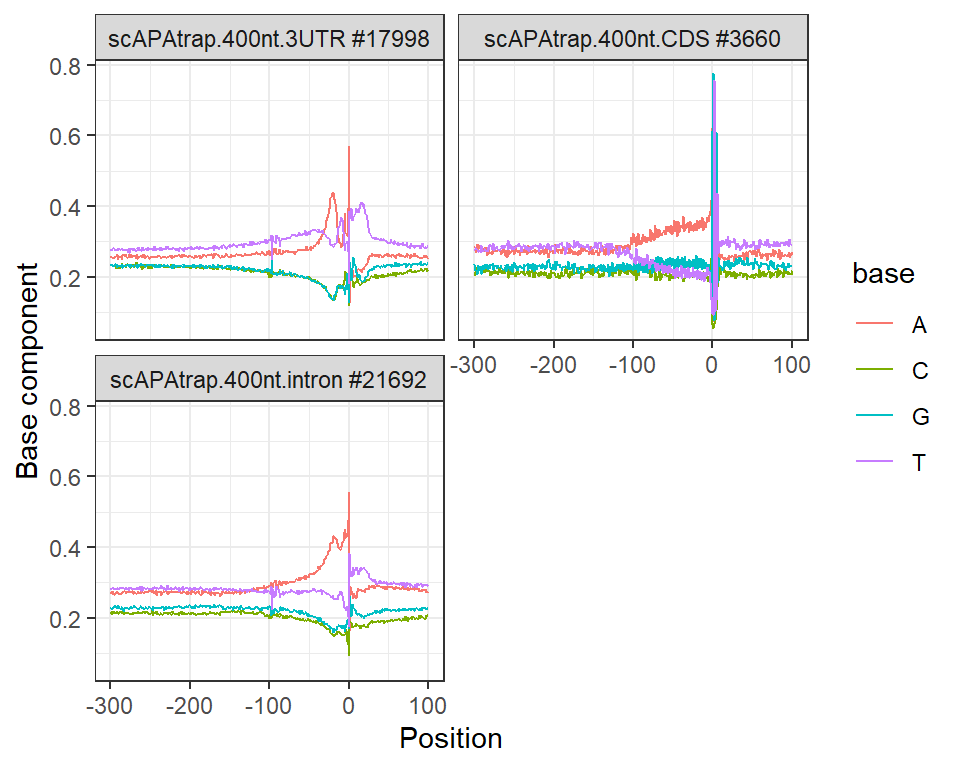

```r
plotATCGforFAfile(fafiles1, ofreq = TRUE, opdf = FALSE, refPos = 301, mergePlots = T, filepre = "scAPAtrap.400nt")
```

```r
## sierra
dsPlot = sierrads[sierrads@anno$ftr %in% c("3UTR", "CDS", "intron")]
fafiles2 = faFromPACds(dsPlot, bsgenome, what = "updn", fapre = "sierra.400nt", up = -300, dn = 100, byGrp = "ftr",
    chrCheck = FALSE)
```

```
## 11150 >>> sierra.400nt.3UTR.fa
## 5505 >>> sierra.400nt.intron.fa
## 3355 >>> sierra.400nt.CDS.fa
```

```
## >>> sierra.400nt.3UTR.sierra.400nt.freq
## >>> sierra.400nt.intron.sierra.400nt.freq
## >>> sierra.400nt.CDS.sierra.400nt.freq
```

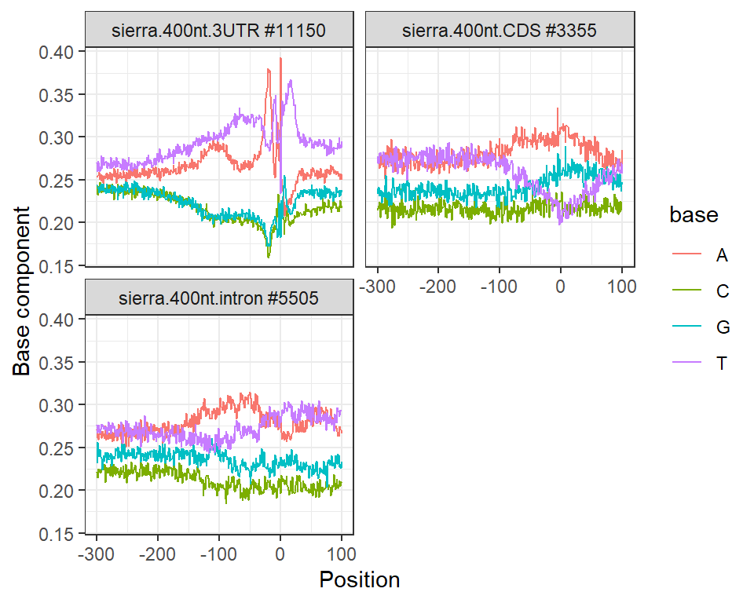

```r
plotATCGforFAfile(fafiles2, ofreq = TRUE, opdf = FALSE, refPos = 301, mergePlots = T, filepre = "sierra.400nt")
```

```r
## scAPA
dsPlot = scAPAds[scAPAds@anno$ftr %in% c("3UTR", "CDS", "intron")]
fafiles3 = faFromPACds(dsPlot, bsgenome, what = "updn", fapre = "scAPA.400nt", up = -300, dn = 100, byGrp = "ftr",
    chrCheck = FALSE)
```

```
## 17044 >>> scAPA.400nt.3UTR.fa
## 785 >>> scAPA.400nt.intron.fa
## 344 >>> scAPA.400nt.CDS.fa
```

```
## >>> scAPA.400nt.3UTR.scAPA.400nt.freq
## >>> scAPA.400nt.intron.scAPA.400nt.freq
## >>> scAPA.400nt.CDS.scAPA.400nt.freq
```

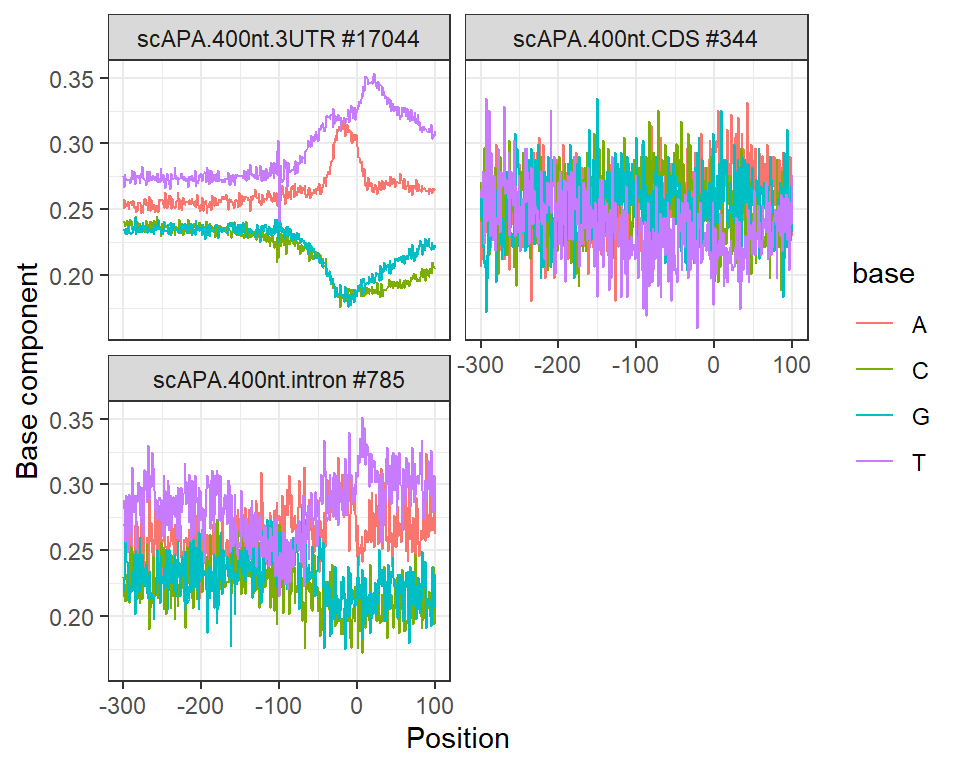

```r
plotATCGforFAfile(fafiles3, ofreq = TRUE, opdf = FALSE, refPos = 301, mergePlots = T, filepre = "scAPA.400nt")
```

```r
## ploysite2.0
mm10polyAsite2<- annotatePAC(mm10polyAsite2,aGFF = txdbmm10)
mm10polyAsite2 <- ext3UTRPACds(mm10polyAsite2, ext3UTRlen=1000)
```

```
## 19027 PACs in extended 3UTR (ftr=intergenic >> ftr=3UTR)
## Get 3UTR length (anno@toStop) for 3UTR/extended 3UTR PACs
```

```r
table(mm10polyAsite2@anno$ftr)
```

```
##
##       3UTR       5UTR        CDS       exon intergenic     intron
##      96703       1173      16251       7408     112697      66527
```

```r
## polyAsite2.0
dsPlot = mm10polyAsite2[mm10polyAsite2@anno$ftr %in% c("3UTR", "CDS", "intron")]
fafiles4 = faFromPACds(dsPlot, bsgenome, what = "updn", fapre = "mm10polyAsite2.400nt", up = -300, dn = 100, byGrp = "ftr",
    chrCheck = FALSE)
```

```
## 66527 >>> mm10polyAsite2.400nt.intron.fa
## 96703 >>> mm10polyAsite2.400nt.3UTR.fa
## 16251 >>> mm10polyAsite2.400nt.CDS.fa
```

```
## >>> mm10polyAsite2.400nt.intron.mm10polyAsite2.400nt.freq
## >>> mm10polyAsite2.400nt.3UTR.mm10polyAsite2.400nt.freq
## >>> mm10polyAsite2.400nt.CDS.mm10polyAsite2.400nt.freq
```

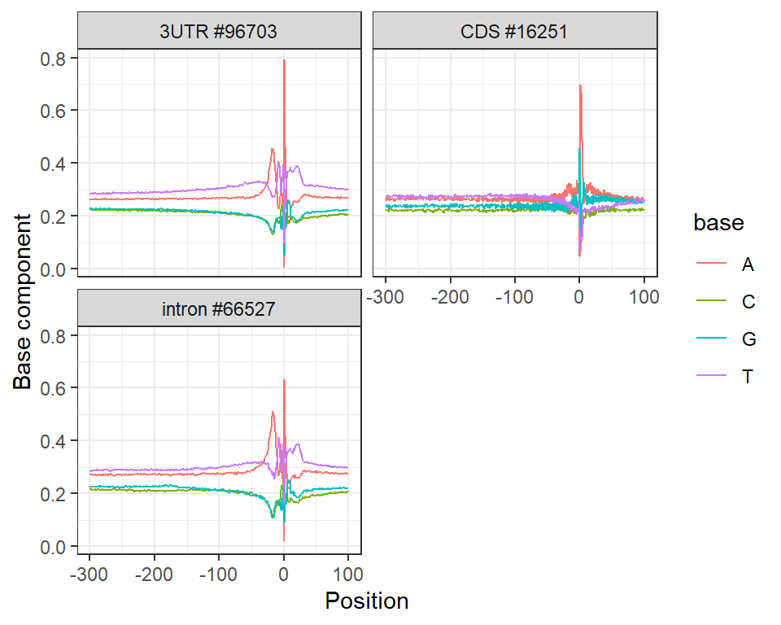

```r
plotATCGforFAfile(fafiles4, ofreq = TRUE, opdf = FALSE, refPos = 301, mergePlots = T, filepre = "mm10polyAsite2.400nt")
```

```r
## ployAdb3
mm10polyAdb3<- annotatePAC(mm10polyAdb3,aGFF = txdbmm10)
mm10polyAdb3 <- ext3UTRPACds(mm10polyAdb3, ext3UTRlen=1000)
```

```
## 26966 PACs in extended 3UTR (ftr=intergenic >> ftr=3UTR)
## Get 3UTR length (anno@toStop) for 3UTR/extended 3UTR PACs
```

```r
table(mm10polyAdb3@anno$ftr)
```

```
##
##       3UTR       5UTR        CDS       exon intergenic     intron
##     123208        720      12776      11039     146249      90327
```

```r
## polyAdb3
dsPlot = mm10polyAdb3[mm10polyAdb3@anno$ftr %in% c("3UTR", "CDS", "intron")]
fafiles = faFromPACds(dsPlot, bsgenome, what = "updn", fapre = "mm10polyAdb3.400nt", up = -300, dn = 100, byGrp = "ftr",
    chrCheck = FALSE)
```

```
## 123208 >>> mm10polyAdb3.400nt.3UTR.fa
## 90327 >>> mm10polyAdb3.400nt.intron.fa
## 12776 >>> mm10polyAdb3.400nt.CDS.fa
```

```
## >>> mm10polyAdb3.400nt.3UTR.mm10polyAdb3.400nt.freq
## >>> mm10polyAdb3.400nt.intron.mm10polyAdb3.400nt.freq
## >>> mm10polyAdb3.400nt.CDS.mm10polyAdb3.400nt.freq
```

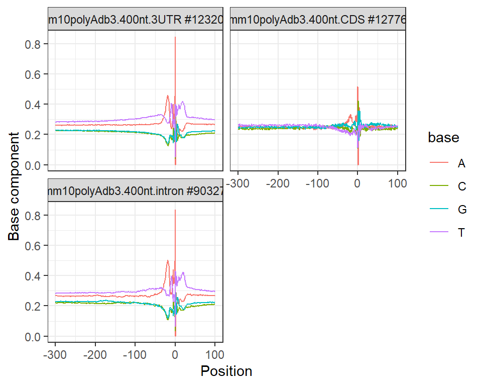

```r
plotATCGforFAfile(fafiles, ofreq = TRUE, opdf = FALSE, refPos = 301, mergePlots = T, filepre = "mm10polyAdb3.400nt")
```

## 1.3 3UTR regional PAC comparison

In this section, we will extract the polyA sites in the 3 UTR regions from the sites identified by the three methods,and discuss the accuracy of the three methods to identify the locus from the two aspects of the polyA signal of the site and the ratio associated with polyA annotationspolyA annotations.

```r
scAPAtrapds3UTR <- scAPAtrapds[scAPAtrapds@anno$ftr=='3UTR',]
scAPAds3UTR <- scAPAds[scAPAds@anno$ftr=='3UTR',]
sierrads3UTR <- sierrads[sierrads@anno$ftr == '3UTR',]
```

### 1.3.1 Basic statistics

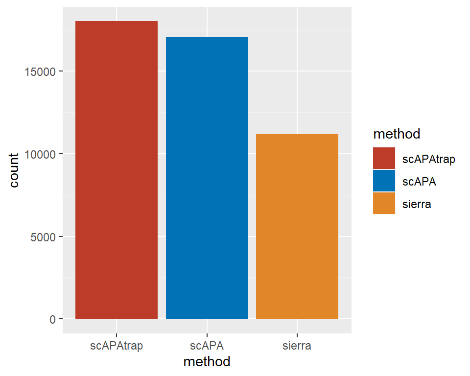

```r
## Three methods 3UTR area PAC number, and draw  histogram
PAC <- c(nrow(scAPAtrapds3UTR@counts),nrow(scAPAds3UTR@counts),nrow(sierrads3UTR@counts))
method <- factor(c('scAPAtrap','scAPA','sierra'),levels = c('scAPAtrap','scAPA','sierra'))

temp <- data.frame(PAC = PAC,method = method)

ggplot(temp) + aes(x = method, fill = method, colour = method,weight = PAC) + geom_bar() + scale_fill_nejm() + scale_color_nejm() + theme()
```

```r
## Number of genes
length(unique(scAPAtrapds3UTR@anno$gene));length(unique(scAPAds3UTR@anno$gene));length(unique(sierrads3UTR@anno$gene))
```

```
## [1] 12387
```

```
## [1] 11811
```

```
## [1] 7938
```

```r
# Number of APA genes
scAPAtrapds3UTRh2 <- get3UTRAPAds(scAPAtrapds3UTR, sortPA = TRUE, choose2PA = NULL)
scAPAds3UTRh2 <- get3UTRAPAds(scAPAds3UTR, sortPA = TRUE, choose2PA = NULL)
sierrads3UTRh2 <- get3UTRAPAds(sierrads3UTR, sortPA = TRUE, choose2PA = NULL)

length(unique(scAPAtrapds3UTRh2@anno$gene));length(unique(scAPAds3UTRh2@anno$gene));length(unique(sierrads3UTRh2@anno$gene))
```

```
## [1] 3484
```

```
## [1] 3789
```

```
## [1] 2246
```

### 1.3.2 Associate polyA annotations

Draw the proportion of polyA annotations associated with each method at different distances.

```r
## polyA site2.0
scAPAtrap.map <- c()
scAPA.map <- c()
Sierra.map <- c()
for (d in 2:20){
  scAPAtrapds3UTR <- annotateByKnownPAC(scAPAtrapds3UTR, mm10polyAsite2, labels="Mm", d=5*d)
  scAPAtrap.map <- c(scAPAtrap.map,sum(scAPAtrapds3UTR@anno$Mm_ovp == 1))
  scAPAds3UTR <- annotateByKnownPAC(scAPAds3UTR, mm10polyAsite2, labels="Mm", d=5*d)
  scAPA.map <- c(scAPA.map,sum(scAPAds3UTR@anno$Mm_ovp == 1))
  sierrads3UTR <- annotateByKnownPAC(sierrads3UTR, mm10polyAsite2, labels="Mm", d=5*d)
  Sierra.map <- c(Sierra.map,sum(sierrads3UTR@anno$Mm_ovp == 1))
}
```

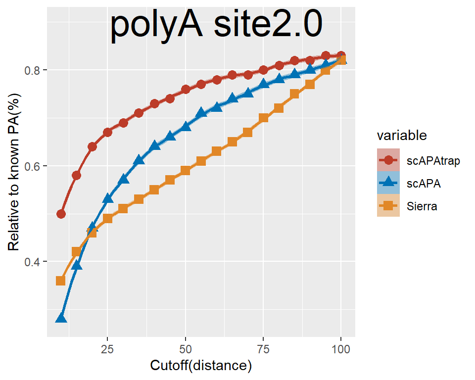

```r
scAPAtrap.map <- round(scAPAtrap.map/length(scAPAtrapds3UTR),2)
scAPA.map <- round(scAPA.map/length(scAPAds3UTR),2)
Sierra.map <- round(Sierra.map/length(sierrads3UTR),2)
d <- c(2:20)*5
all.map <- data.frame(scAPAtrap = scAPAtrap.map,scAPA = scAPA.map, Sierra = Sierra.map,d=d)

all.map <- reshape2::melt(all.map, id = c("d"))

ggplot(all.map) + aes(x = d, y = value, fill = variable, colour = variable, shape = variable) + geom_point(size = 3L) +
    geom_smooth(span = 0.33) + scale_fill_nejm() + scale_color_nejm() + annotate("text", x = 60, y = 0.9, label = "polyA site2.0",
    family = "Arial", size = 10L) + labs(x = "Cutoff(distance)", y = "Relative to known PA(%)") + theme()
```

```r
## polyA db3
scAPAtrap.map <- c()
scAPA.map <- c()
Sierra.map <- c()
for (d in 2:20){
  scAPAtrapds3UTR <- annotateByKnownPAC(scAPAtrapds3UTR, mm10polyAdb3, labels="Mm", d=5*d)
  scAPAtrap.map <- c(scAPAtrap.map,sum(scAPAtrapds3UTR@anno$Mm_ovp == 1))
  scAPAds3UTR <- annotateByKnownPAC(scAPAds3UTR, mm10polyAdb3, labels="Mm", d=5*d)
  scAPA.map <- c(scAPA.map,sum(scAPAds3UTR@anno$Mm_ovp == 1))
  sierrads3UTR <- annotateByKnownPAC(sierrads3UTR, mm10polyAdb3, labels="Mm", d=5*d)
  Sierra.map <- c(Sierra.map,sum(sierrads3UTR@anno$Mm_ovp == 1))
}
```

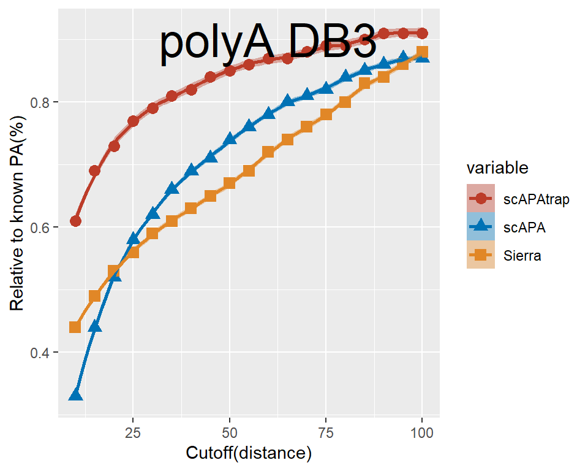

```r
scAPAtrap.map <- round(scAPAtrap.map/length(scAPAtrapds3UTR),2)
scAPA.map <- round(scAPA.map/length(scAPAds3UTR),2)
Sierra.map <- round(Sierra.map/length(sierrads3UTR),2)
d <- c(2:20)*5
all.map <- data.frame(scAPAtrap = scAPAtrap.map,scAPA = scAPA.map, Sierra = Sierra.map,d=d)

all.map <- reshape2::melt(all.map, id = c("d"))

ggplot(all.map) + aes(x = d, y = value, fill = variable, colour = variable, shape = variable) + geom_point(size = 3L) +
    geom_smooth(span = 0.33) + scale_fill_nejm() + scale_color_nejm() + annotate("text", x = 60, y = 0.9, label = "polyA DB3",
    family = "Arial", size = 10L) + labs(x = "Cutoff(distance)", y = "Relative to known PA(%)") + theme()
```

### 1.3.3 Distribution of the distance from the real site

In this part, we associate the sites identified by the three methods to the polyAsite2.0 annotation sites with a distance of d=100, and observe the distribution of the distances of the associated annotation sites when d=100.

```r
scAPAtrapds3UTR <- annotateByKnownPAC(scAPAtrapds3UTR, mm10polyAsite2, labels = "Mm", d = 100)
```

```
## query: 17998
## known: 300759 ( Mm )
## 14986 query PACs overlapping known PACs
```

```r
scAPAds3UTR <- annotateByKnownPAC(scAPAds3UTR, mm10polyAsite2, labels = "Mm", d = 100)
```

```
## query: 17044
## known: 300759 ( Mm )
## 13979 query PACs overlapping known PACs
```

```r
sierrads3UTR <- annotateByKnownPAC(sierrads3UTR , mm10polyAsite2, labels = "Mm", d = 100)
```

```
## query: 11150
## known: 300759 ( Mm )
## 9112 query PACs overlapping known PACs
```

```r
sum(na.omit(scAPAtrapds3UTR@anno$Mm_dist))/sum(!is.na(scAPAtrapds3UTR@anno$Mm_dist));
```

```
## [1] 31.44955
```

```r
sum(na.omit(scAPAds3UTR@anno$Mm_dist))/sum(!is.na(scAPAds3UTR@anno$Mm_dist));
```

```
## [1] 41.5308
```

```r
sum(na.omit(sierrads3UTR@anno$Mm_dist))/sum(!is.na(sierrads3UTR@anno$Mm_dist))
```

```
## [1] 45.04653
```

Plot the distribution of distance.

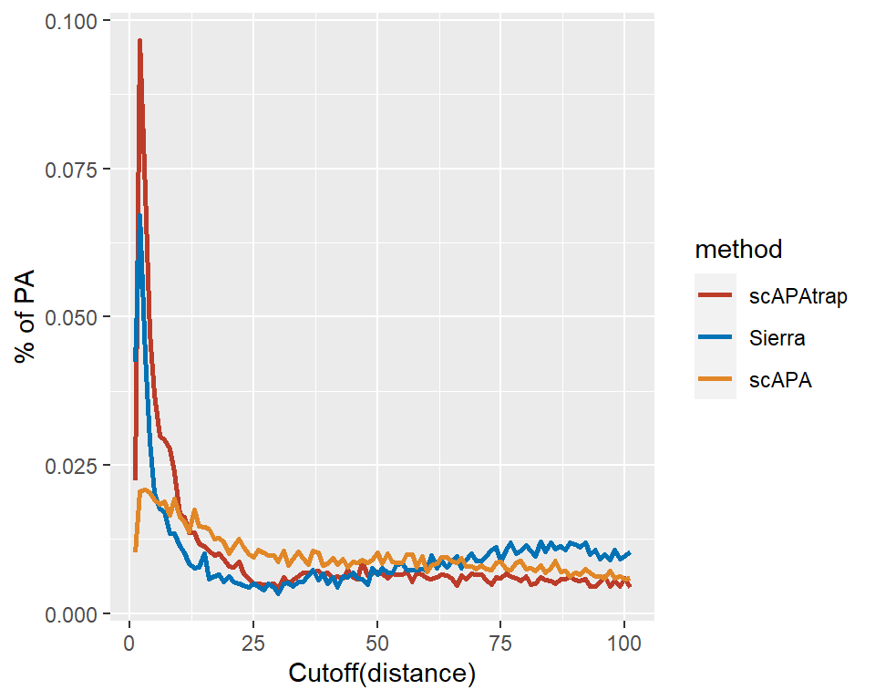

```r
scAPA.dist <- as.data.frame(table(na.omit(scAPAds3UTR@anno$Mm_dist)))
scAPAtrap.dist <- as.data.frame(table(na.omit(scAPAtrapds3UTR@anno$Mm_dist)))
sierra.dist <- as.data.frame(table(na.omit(sierrads3UTR@anno$Mm_dist)))
scAPA.dist$Freq <- scAPA.dist$Freq/sum(scAPA.dist$Freq)
scAPAtrap.dist$Freq <- scAPAtrap.dist$Freq/sum(scAPAtrap.dist$Freq)
sierra.dist$Freq <- sierra.dist$Freq/sum(sierra.dist$Freq)
scAPA.dist$method <- rep("scAPA", length(scAPA.dist$Freq))
scAPAtrap.dist$method <- rep("scAPAtrap", length(scAPAtrap.dist$Freq))
sierra.dist$method <- rep("Sierra", length(sierra.dist$Freq))

all_dist <- rbind(scAPA.dist, scAPAtrap.dist, sierra.dist)
all_dist$Var1 <- as.numeric(all_dist$Var1)
all_dist$Var1 <- all_dist$Var1
all_dist$method <- factor(all_dist$method, levels = c("scAPAtrap", "Sierra", "scAPA"))
ggplot(all_dist) + aes(x = Var1, y = Freq, fill = method, colour = method) + geom_line(size = 1L) + scale_fill_nejm() +
    scale_color_nejm() + labs(x = "Cutoff(distance)", y = "% of PA", fill = "method", color = "method") + theme()
```

### 1.3.4 Calculation of polyA signal

```r
## Imported mouse polyA signal
load('C:/Users/admin/Desktop/refdata/mm10Signal.rda')
## Set priority
priority <- c(1, 2, rep(3, 16))
```

```r
## scAPAtrap
scAPAtrapds3UTR <- annotateByPAS(pacds = scAPAtrapds3UTR, bsgenome, grams = mm10Signal, priority = priority, from = -60, to = 10,
    label = "Mm", chrCheck = TRUE)
table(scAPAtrapds3UTR@anno$Mm_gram)
```

```
##
## AACAAA AACAAG AAGAAA AATAAA AATAAG AATAAT AATACA AATAGA AATATA AATGAA ACTAAA
##    291    114    399   8591    106    196    312    137    291    257    163
## AGTAAA ATTAAA ATTACA ATTATA CATAAA GATAAA TATAAA
##    414   2400    127    137    260    206    378
```

```r
sum(!is.na(scAPAtrapds3UTR@anno$Mm_gram))/length(scAPAtrapds3UTR)
```

```
## [1] 0.8211468
```

```r
## scAPA
scAPAds3UTR <- annotateByPAS(pacds = scAPAds3UTR, bsgenome, grams = mm10Signal, priority = priority, from = -60, to = 10,
    label = "Mm", chrCheck = TRUE)
table(scAPAds3UTR@anno$Mm_gram)
```

```
##
## AACAAA AACAAG AAGAAA AATAAA AATAAG AATAAT AATACA AATAGA AATATA AATGAA ACTAAA
##    329    143    417   5122    138    204    274    145    306    300    165
## AGTAAA ATTAAA ATTACA ATTATA CATAAA GATAAA TATAAA
##    350   1621    153    200    264    204    443
```

```r
sum(!is.na(scAPAds3UTR@anno$Mm_gram))/length(scAPAds3UTR)
```

```
## [1] 0.6323633
```

```r
## sierra
sierrads3UTR <- annotateByPAS(pacds = sierrads3UTR, bsgenome, grams = mm10Signal, priority = priority, from = -60, to = 10,
    label = "Mm", chrCheck = TRUE)
table(sierrads3UTR@anno$Mm_gram)
```

```
##
## AACAAA AACAAG AAGAAA AATAAA AATAAG AATAAT AATACA AATAGA AATATA AATGAA ACTAAA
##    202    118    271   3573     92    112    152     97    154    168     87
## AGTAAA ATTAAA ATTACA ATTATA CATAAA GATAAA TATAAA
##    217    915     81    100    142     91    227
```

```r
sum(!is.na(sierrads3UTR@anno$Mm_gram))/length(sierrads3UTR)
```

```
## [1] 0.6097758
```

Draw the proportion of each method signal

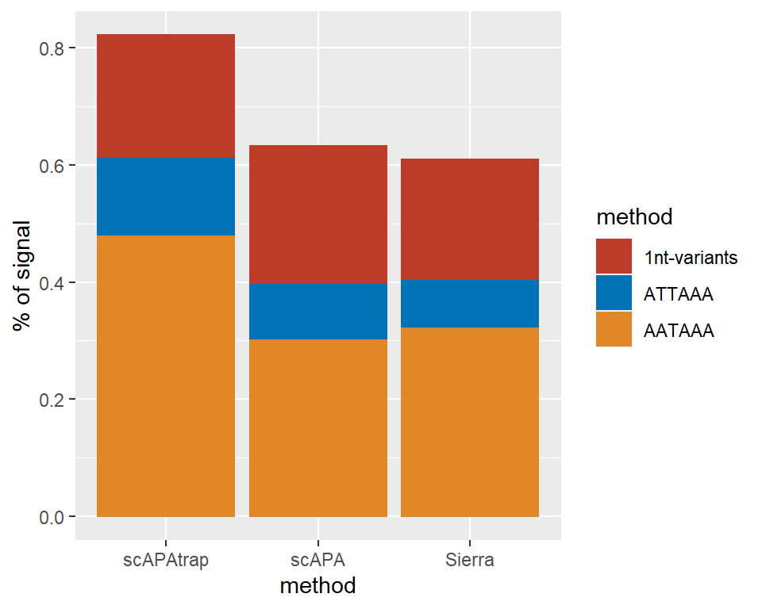

```r
scAPA.signal <- scAPAds3UTR@anno$Mm_gram[!is.na(scAPAds3UTR@anno$Mm_gram)]
scAPA.signal[!scAPA.signal %in% c("AATAAA", "ATTAAA")] <- "1nt-variants"
scAPA.signal <- as.data.frame(table(scAPA.signal))
scAPA.signal$Freq <- scAPA.signal$Freq/length(scAPAds3UTR@anno$Mm_gram)
scAPA.signal$methed <- rep("scAPA", length(scAPA.signal$Freq))
colnames(scAPA.signal) <- c("signal", "freq", "method")

scAPAtrap.signal <- scAPAtrapds3UTR@anno$Mm_gram[!is.na(scAPAtrapds3UTR@anno$Mm_gram)]
scAPAtrap.signal[!scAPAtrap.signal %in% c("AATAAA", "ATTAAA")] <- "1nt-variants"
scAPAtrap.signal <- as.data.frame(table(scAPAtrap.signal))
scAPAtrap.signal$Freq <- scAPAtrap.signal$Freq/length(scAPAtrapds3UTR@anno$Mm_gram)
scAPAtrap.signal$methed <- rep("scAPAtrap", length(scAPAtrap.signal$Freq))
colnames(scAPAtrap.signal) <- c("signal", "freq", "method")

sierra.signal <- sierrads3UTR@anno$Mm_gram[!is.na(sierrads3UTR@anno$Mm_gram)]
sierra.signal[!sierra.signal %in% c("AATAAA", "ATTAAA")] <- "1nt-variants"
sierra.signal <- as.data.frame(table(sierra.signal))
sierra.signal$Freq <- sierra.signal$Freq/length(sierrads3UTR@anno$Mm_gram)
sierra.signal$methed <- rep("Sierra", length(sierra.signal$Freq))
colnames(sierra.signal) <- c("signal", "freq", "method")

all_signal <- rbind(scAPAtrap.signal, scAPA.signal, sierra.signal)
all_signal$signal = factor(all_signal$signal, levels = c("1nt-variants", "ATTAAA", "AATAAA"))
all_signal$method <- factor(all_signal$method, levels = c("scAPAtrap", "scAPA", "Sierra",'Bulk'))
ggplot(all_signal) + aes(x = method, fill = signal, colour = signal, weight = freq) + geom_bar(position = "stack") + scale_fill_nejm() +
    scale_color_nejm() + labs(y = "% of signal", fill = "method", color = "method") + theme()
```

### 1.3.5 PAC’s overlaping

```r
scAPAtrapds3UTR.G<- with(scAPAtrapds3UTR@anno, GRanges(seqnames = chr, ranges = IRanges(start = start, end = end), strand = strand))
scAPAds3UTR.G <- with(scAPAds3UTR@anno, GRanges(seqnames = chr, ranges = IRanges(start = start, end = end), strand = strand))
sierrads3UTR.G <- with(sierrads3UTR@anno, GRanges(seqnames = chr, ranges = IRanges(start = start, end = end), strand = strand))

ov <- ChIPpeakAnno::findOverlapsOfPeaks(scAPAtrapds3UTR.G, scAPAds3UTR.G, sierrads3UTR.G , ignore.strand = FALSE)
```

```
## duplicated or NA names found.
##                 Rename all the names by numbers.
## duplicated or NA names found.
##                 Rename all the names by numbers.
## duplicated or NA names found.
##                 Rename all the names by numbers.
```

```r
ChIPpeakAnno::makeVennDiagram(ov, fill = c("#FF69B4", "#32CD32", "#FFFF00"))
```

```
## Missing totalTest! totalTest is required for HyperG test.
## If totalTest is missing, pvalue will be calculated by estimating
## the total binding sites of encoding region of human.
## totalTest = humanGenomeSize * (2%(codingDNA) +
##              1%(regulationRegion)) / ( 2 * averagePeakWidth )
##           = 3.3e+9 * 0.03 / ( 2 * averagePeakWidth)
##           = 5e+7 /averagePeakWidth
```

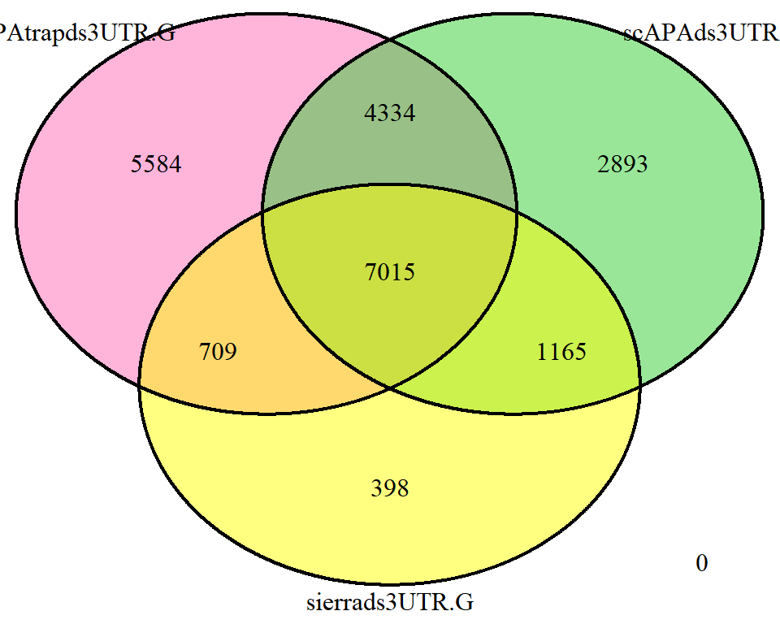

## 1.4 Identification of low expression PAC

In this section, we will discuss the effects of the three methods on low-expressed PAC recognition. ### Basic statistics Here we think that the total expression level is less than 30 as a low expression level, so cutoff is set to 30.

```r
cutoff <- 30
scAPAtrapds3UTR.low <- scAPAtrapds3UTR[rowSums(scAPAtrapds3UTR@counts) <= cutoff, ]
scAPAds3UTR.low <- scAPAds3UTR[rowSums(scAPAds3UTR@counts) <= cutoff, ]
sierrads3UTR.low <- sierrads3UTR[rowSums(sierrads3UTR@counts) <= cutoff, ]
```

Number of low-expressed PACs by each method

```r
length(scAPAtrapds3UTR.low);length(scAPAds3UTR.low);length(sierrads3UTR.low)
```

```
## [1] 4210
```

```
## [1] 2714
```

```
## [1] 193
```

Number of PACs with low expression and polyA signal

```r
sum(!is.na(scAPAtrapds3UTR.low@anno$Mm_gram));sum(!is.na(scAPAds3UTR.low@anno$Mm_gram));sum(!is.na(sierrads3UTR.low@anno$Mm_gram))
```

```
## [1] 3318
```

```
## [1] 877
```

```
## [1] 137
```

Ratio of PACs with low expression and polyA signal

```r
sum(!is.na(scAPAtrapds3UTR.low@anno$Mm_gram))/length(scAPAtrapds3UTR.low);  # [1] 0.781797
```

```
## [1] 0.7881235
```

```r
sum(!is.na(scAPAds3UTR.low@anno$Mm_gram))/length(scAPAds3UTR.low);
```

```
## [1] 0.3231393
```

```r
sum(!is.na(sierrads3UTR.low@anno$Mm_gram))/length(sierrads3UTR.low);
```

```
## [1] 0.7098446
```

Number of polyA annotations associated with low expression PAC

```r
sum(scAPAtrapds3UTR.low@anno$Mm_ovp);sum(scAPAds3UTR.low@anno$Mm_ovp);sum(sierrads3UTR.low@anno$Mm_ovp)
```

```
## [1] 3137
```

```
## [1] 1530
```

```
## [1] 177
```

Ratio of polyA annotations associated with low expression PAC

```r
sum(scAPAtrapds3UTR.low@anno$Mm_ovp)/length(scAPAtrapds3UTR.low);sum(scAPAds3UTR.low@anno$Mm_ovp)/length(scAPAds3UTR.low);sum(sierrads3UTR.low@anno$Mm_ovp)/length(sierrads3UTR.low);
```

```
## [1] 0.7451306
```

```
## [1] 0.5637436
```

```
## [1] 0.9170984
```

### 1.4.1 Overlapping of low expression PAC

```r
scAPAtrap.g_low <- with(scAPAtrapds3UTR.low@anno, GRanges(seqnames = chr, ranges = IRanges(start = start, end = end), strand = strand))
scAPA.g_low <- with(scAPAds3UTR.low@anno, GRanges(seqnames = chr, ranges = IRanges(start = start, end = end), strand = strand))
sierra.g_low <- with(sierrads3UTR.low@anno, GRanges(seqnames = chr, ranges = IRanges(start = start, end = end), strand = strand))

ov1 <- ChIPpeakAnno::findOverlapsOfPeaks(scAPAtrap.g_low , scAPA.g_low,sierra.g_low, ignore.strand = FALSE)
```

```
## duplicated or NA names found.
##                 Rename all the names by numbers.
## duplicated or NA names found.
##                 Rename all the names by numbers.
## duplicated or NA names found.
##                 Rename all the names by numbers.
```

```r
ChIPpeakAnno::makeVennDiagram(ov1, fill = c("#FF69B4", "#32CD32", "#FFFF00"))
```

```
## Missing totalTest! totalTest is required for HyperG test.
## If totalTest is missing, pvalue will be calculated by estimating
## the total binding sites of encoding region of human.
## totalTest = humanGenomeSize * (2%(codingDNA) +
##              1%(regulationRegion)) / ( 2 * averagePeakWidth )
##           = 3.3e+9 * 0.03 / ( 2 * averagePeakWidth)
##           = 5e+7 /averagePeakWidth
```

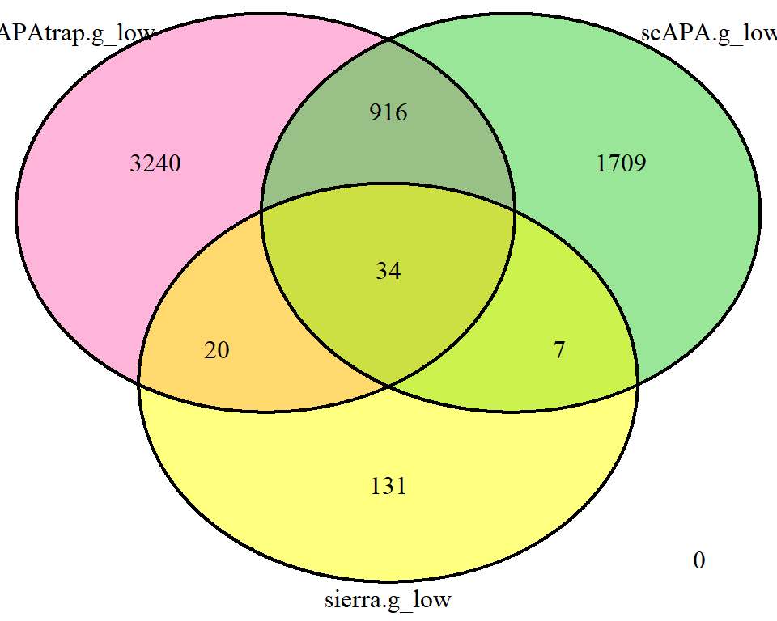

### 1.4.2 motif and ATCG distribution map drawing

```r
## ATCG distribution map
fafiles = faFromPACds(scAPAtrapds3UTR.low, bsgenome, what = "updn", fapre = "scAPAtrap3UTR.low", up = -300, dn = 100, chrCheck = FALSE)
```

```
## 4210 >>> scAPAtrap3UTR.low.fa
```

```
## >>> scAPAtrap3UTR.low.scAPAtrap3UTR.low.freq
```

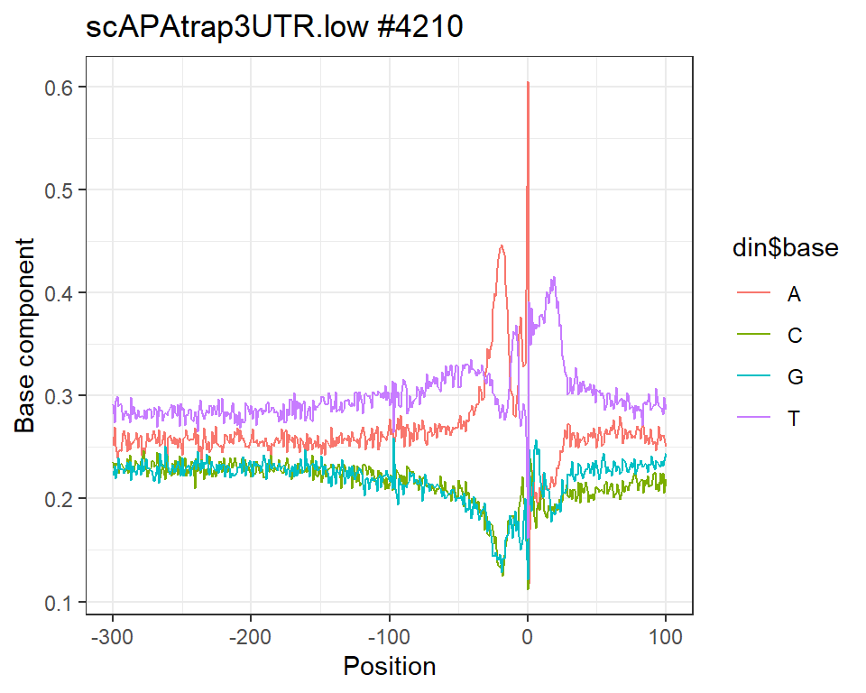

```r
plotATCGforFAfile(fafiles, ofreq = TRUE, opdf = F, refPos = 301, mergePlots = F, filepre = "scAPAtrap3UTR.low")
```

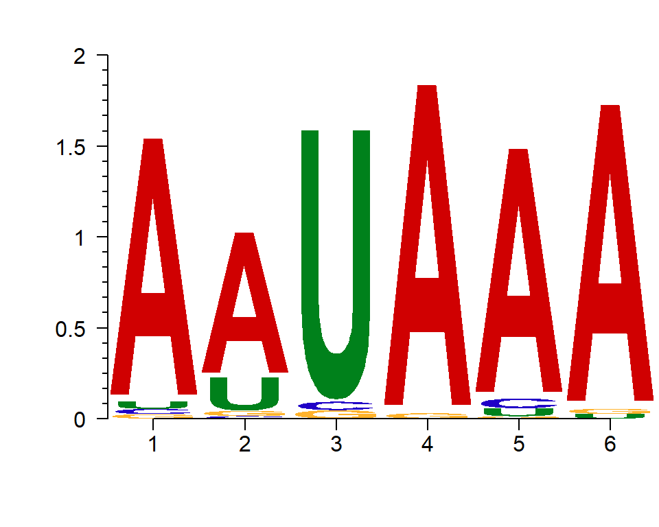

```r
## motif
pas = scAPAtrapds3UTR.low@anno$Mm_gram[!is.na(scAPAtrapds3UTR.low@anno$Mm_gram)]
plotSeqLogo(pas)
```

### 1.4.3 The effect of low expression PAC on the number of genes

Changes in the number of genes before and after the introduction of low expression PAC

```r
scAPAtrapds3UTR.upper <- scAPAtrapds3UTR[rowSums(scAPAtrapds3UTR@counts) > cutoff, ]
temp1 <- dplyr::group_by(scAPAtrapds3UTR.upper@anno, gene) %>% summarise(count = n())
temp2 <- dplyr::group_by(scAPAtrapds3UTR@anno, gene) %>% summarise(count = n())
```

```r
temp1_num <- c()
temp2_num <- c()
for (i in c(1:5)) {
    if (i < 5) {
        temp1_num <- c(temp1_num, sum(temp1$count == i))
        temp2_num <- c(temp2_num, sum(temp2$count == i))
    } else {
        temp1_num <- c(temp1_num, sum(temp1$count >= i))
        temp2_num <- c(temp2_num, sum(temp2$count >= i))
    }
}

nPAC <- paste0(c("=", "=", "=", "=", ">="), c(1:5))
lowplot <- data.frame(before = temp1_num, after = temp2_num, nPAC = nPAC)
lowplot
```

```
##   before after nPAC
## 1   7633  8896   =1
## 2   1859  2534   =2
## 3    445   712   =3
## 4     92   166   =4
## 5     27    79  >=5
```

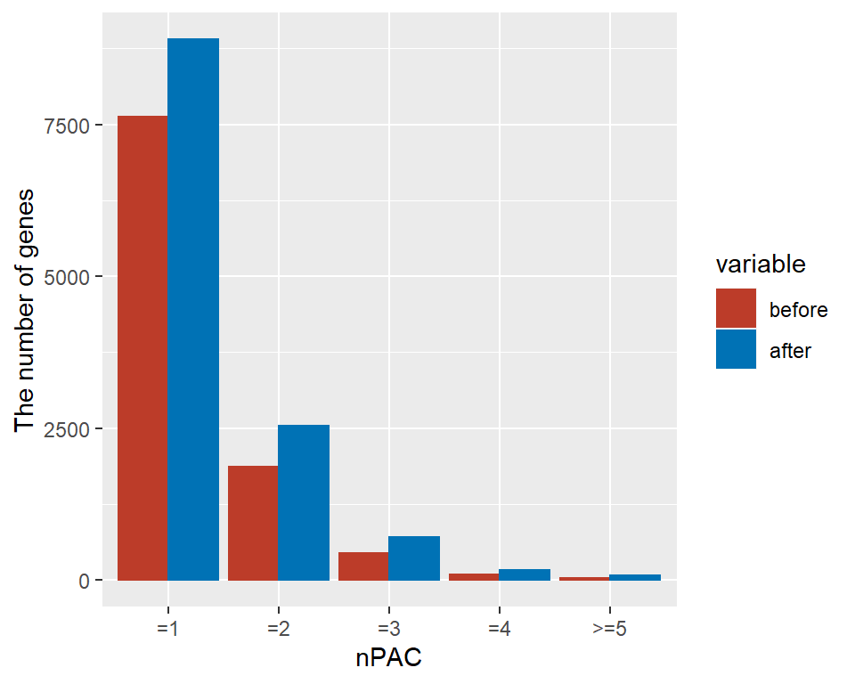

```r
lowplot <- reshape2::melt(lowplot, id = c("nPAC"))
ggplot(lowplot) + aes(x = nPAC, fill = variable, colour = variable, weight = value) + geom_bar(position = "dodge") + scale_fill_nejm() +
    scale_color_nejm() + labs(y = "The number of genes") + theme()
```

# 3 References

[1] Shulman, E.D. and Elkon, R. Cell-type-specific analysis of alternative polyadenylation using single-cell transcriptomics data. Nucleic Acids Res 2019;47(19):10027-10039.

[2] movAPA: Modeling and visualization of dynamics of alternative polyadenylation across biological samples (under review).

[3] Lukassen, S., et al. (2018) Single-cell RNA sequencing of adult mouse testes, Scientific Data, 5, 180192.

[4] Sierra: discovery of differential transcript usage from polyA-captured single-cell RNA-seq data